# Coursework Report

*N* removed NAs: 3

*N* removed typo: 1

*N* removed <18: 20

*N* total clean: 126

| Group | *N* | *M*<sub>age</sub> | *M*<sub>rating</sub> |
| --- | --- | --- | --- |
| Control | 64 | 20.9 | 5.9 |
| Experim | 62 | 20.6 | 6.8 |

**Main analysis results**

*t*(124) = -6.22, *p* < .001

[interactive chart not shown]

[figure not shown]

[interactive chart not shown]

# Coursework Report

Analysing Data, Spring 2020

# Methods

## Participants

Table 1 *Descriptive statistics by Group*

[output not shown]

## Design

In this experiment, the conceptual hypothesis to be researched is ‘Does colour influence attractiveness?’.The key operationalised independent variable being manipulated in this study is the colour of the background used behind the image of the moderately attractive male. This independent variable, as a factor, consists of two levels; a red background and a white background. The key operationalised dependent variable measured in this study is the rating of perceived attractiveness on a scale of 1-9, collected for 3 different questions. Across this scale, a rating of 1 represents ‘not at all attractive’, with a rating of 9 representing ‘extremely attractive’. The operational hypothesis of this experiment is ‘Does viewing a different colour background (red or white) behind an image of a moderately attractive man influence the mean ratings of his attractiveness across a scale of 1-9?’. To test this, statistical analysis will be carried out via a t-test.

# Results

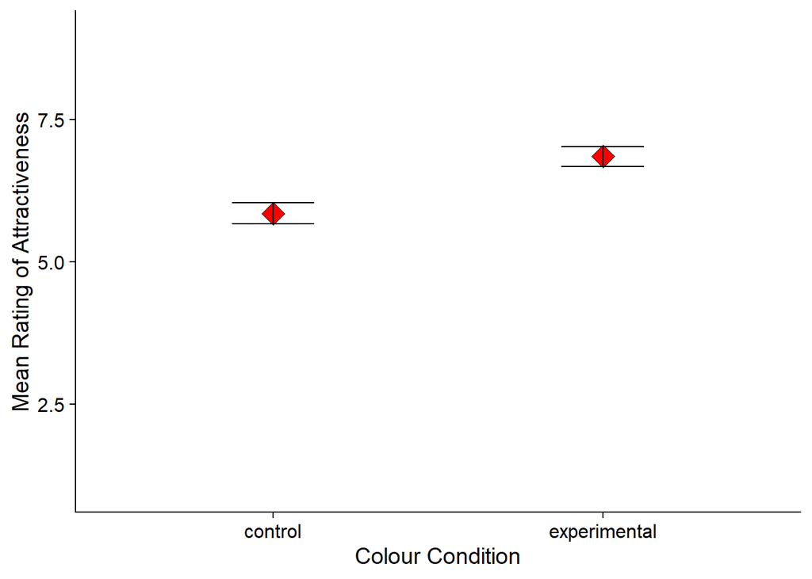

# Discussion

From this replication study, the final results gathered demonstrate that the overall rating of perceived attractiveness was higher for those participants in the red background experimental condition, compared to individuals in the white background control condition. These results indicate that the manipulation of the independent variable of colour did make a significant difference to ratings of attractiveness outcomes.

When looking further into developments researching the red effect, controversial findings are apparent. Hesslinger et al (2015) replicated Elliot et al’s (2010) original study, gathering results that demonstrate only a small difference between average ratings across red and white conditions, not being statistically significant. Controversially, in this adapted replication they found instead that apparel style had a significant effect of attractiveness rating, with ratings being higher for males dressed in formal attire compared to casual attire. These findings do not follow the same pattern of results as ours, but do, however, shine a light on a potential new area of interest involving other variables that may impact perceived attractiveness other than colour. Another replication, by Peperkoorn et al (2016) further disputes the reliability of the red effect, demonstrated by their findings which show no significant difference between rating of attractiveness when shown a picture of a women wearing either a red, white, or black t-shirt. Instead, they found results that contradict our own, with participants assigned to the white condition rating the females as more attractive compared to either the red or black conditions; introducing the white effect. These replication attempts suggest that further research should be considered in this area, as there are evident inconsistencies found with varying results for and against the validity of the red effect. It can be seen that other variables, such as apparel and gender, may impact attractiveness decisions, with some being potentially more influential than the colour red itself. As a result, I think this does impact the credibility of the red effect, considering the plethora of replications that dispute the findings of Elliot et al’s (2010) study and our own.

When looking at our study, the independent groups design used can be viewed as a strength when it comes to supporting the effect we are researching. This method of experimental design helps to exclude any order effects that may have affected the results if it were a repeated measures design. For example, the likelihood of demand characteristics is minimised, as well as reducing the possible effects of fatigue and boredom, as participants only take part in one condition. This will consequently lead to more valid results, as these unhelpful elements are removed. Furthermore, another strength of this studies design, which provides more support for the validity of the effect we are interested in, is the use of 3 separate items to measure ratings of attractiveness. Doing this means that we look beyond the single rating of attractiveness, but instead include other elements which may also be influenced by the colour red; broadening the scope of these findings. It allows a deeper look into whether the red effect accounts for certain aspects of attractiveness more than others. On the other hand, there are some limitations to this study that may hinder whether or not this effect is real or not. For example, the sample size is quite small. Making this larger will help to generalise these results, and see if the effects can be applied to the wider population. Furthermore, individual differences may play a role in the validity of the support gathered for the red effect. Participants only took part in one condition, meaning that their response to the other condition was not collected, when it could have been valid in potentially contradicting what was thought to be found. For example, a woman scoring high in the red condition, may have scored even higher in the white condition if exposed to it, eliminating an essential finding. Furthermore, individual differences are definitely apparent in perceived attraction, therefore these might not be great methods to make judgements off of when it comes to validating the red effect theory.

Based on the analysis of the results of my own study it would seem that the red effect is valid based on the significant results we collected. However, I believe that this research question is worth investigating further due to the amount of disputing evidence. To improve, extra variables should be accounted for such as apparel, as well as altering the experimental design to gain more comparative results. Larger sample sizes could be used to gain more generalisable results, as well as possibly extending the sample beyond heterosexual individuals by including homosexual individuals as well.

In conclusion, the findings of my final replication study were consistent with the results of Elliot et al (2010) original study, suggesting the validity and statistical significance of the red effect. Both the original and our replication found the same pattern of results with participants giving higher ratings of perceived attractiveness when in the red condition, compared to the white condition; indicating that colour had a significant difference on rating of attractiveness outcome. However, from further investigation, we can only suggest that the red effect is apparent in some situations, as extended research has highlighted its potential flaws, and insignificant findings amongst replications.

# References

Elliot, A. J., Kayser, D. N., Greitemeyer, T., Lichtenfeld, S., Gramzow, R. H., Maier, M. A., & Liu, H. (2010). Red, Rank, and Romance in Women Viewing Men. Journal of Experimental Psychology: General, 139(3), 399–417.

Hesslinger, V. M., Goldbach, L., Carbon, C. C. (2015) Men in red: A reexamination of the red-attractiveness effect. Psychonomic Bulletin & Review 22, 1142–1148.

Peperkoorn, L. S., Roberts, S. C., & Pollet, T. V. (2016). Revisiting the Red Effect on attractiveness and Sexual Receptivity: No Effect of the Color Red on Human Mate Preferences. Evolutionary Psychology, 14(4), 1–13.